# Getting Started with R

# 4. Functions

## 4.1 Using basic functions

R provides a variety of built-in functions designed to handle common operations and perform statistical analyses. Using a function is straightforward: simply write the function’s name followed by the data it should process, enclosed in parentheses. Here a list of examples:

```r
f<-c(1,10,50,200,300,500,1000)
f
```

```
## [1]    1   10   50  200  300  500 1000
```

```r
min(f)
```

```
## [1] 1
```

```r
max(f)
```

```
## [1] 1000
```

```r
mean(f)
```

```
## [1] 294.4286
```

```r
median(f)
```

```
## [1] 200
```

```r
round(mean(f))
```

```
## [1] 294
```

```r
round(mean(f),digits = 2)
```

```
## [1] 294.43
```

R includes more than 1,000 core functions, with new ones being added regularly. This makes it challenging to remember and master all of them. Fortunately, every R function has a dedicated help page that you can easily access. To view it, simply type help(“name of function”) or ?name of function in the console. For example

```r
?mean
```

or

```r
help("mean")
```

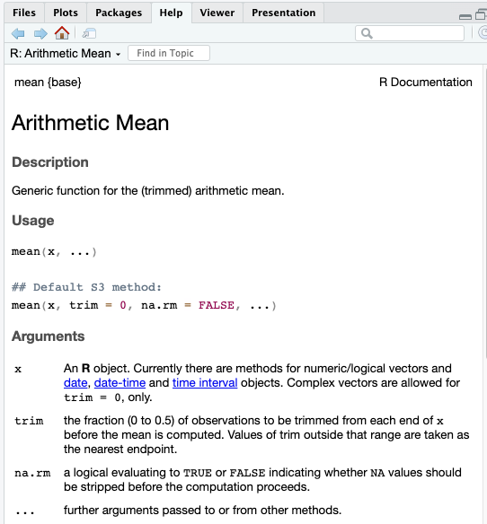

Help pages in R are typically divided into sections, which may vary but often include:

- **Description**: A brief description of the function’s purpose.
- **Usage**: An example of how to write the function, showing the expected order of arguments.
- **Arguments**: A list of the function’s arguments, the required input types, and how they are used.
- **Details**: A deeper explanation of the function and important notes for its usage.
- **Value**: Information about what the function returns.
- **See Also**: Related functions for further exploration.
- **Examples**: Working example code that demonstrates the function in action. This is one of the most useful sections of a help page because these examples demonstrate how the function works and offer an excellent way to learn through practice.

If you want to find the help page for a function but can’t remember its name, you can perform a keyword search by typing help.search(“name of the function”) or two question marks followed by the keyword in R’s command line ??name of function. For example:

```r
??mean
```

R will return a list of relevant functions related to the keyword. In addition, R has a highly active and supportive community of users that you can reach out to for help and resources.An excellent resource for R-related questions is [Stack Overflow](https://stackoverflow.com/), a platform where programmers can answer queries, and users can rank answers based on their usefulness. You can either submit your own questions or search through the extensive archive of previously answered R-related queries.

## 4.2 writing your own functions

In this section, we will explore how to write your own function in R. When you find yourself repeatedly performing the same task, it’s inefficient to copy and paste the code each time. Instead, it’s more practical to define a function once and simply call it whenever needed. After being defined, a custom function operates just like the built-in functions or those from packages that we’ve previously discussed. Below is the fundamental syntax for creating a function in R:

```r
function_name <- function(arguments) {
  result <- expression_to_evaluate #code to execute
  return(result)
}
```

Each function in R consists of three main components: a name, a set of arguments, and a body of code. To create your own function, you need to define these parts and store them in an R object, which can be done using the command `function()`.

Once the function is defined, you can run it as follows: function_name(arguments)

Let us try an example of a function summing two numbers.

```r
sum_numbers<-function(x,y){
  sum<- x+y
  return(sum)
}
```

Just a brief explanatio of the code above:

- **sum_numbers** is the name of the function.
- **x** and **y** are the parameters (inputs) to the function.
- **sum <- x+y** is the calculation that happens inside the function.
- **return(sum)** ensures that the sum is returned when the function is called.

Once you defined the function, you can sum two numbers:

```r
sum_numbers(3,7)
```

```
## [1] 10
```

We can also create a function returning multiple values. In this example, we create a function providing some statistics from a set of values.

```r
calculate_stats <- function(numbers) {
  mean_value <- mean(numbers)
  sum_value <- sum(numbers)
  min_value <- min(numbers)
  max_value <- max(numbers)

  # Returning multiple values in a list
  result <- list(mean = mean_value, sum = sum_value, min = min_value, max = max_value)
  return(result)
}

# Call the function
calculate_stats(c(1, 5, 10, 30, 100))
```

```
## $mean
## [1] 29.2
##
## $sum
## [1] 146
##
## $min
## [1] 1
##
## $max
## [1] 100
```

# 5. Advanced tools: control structures in R.

Control structures in R help determine how your code runs, allowing it to make decisions and repeat actions based on certain conditions. Instead of running the same code every time, control structures let your program react to different inputs or data.

Here are some common control structures in R:

- **if** and **else**: Check a condition and decide what to do based on the result.
- **for**: Repeats a task (loop) a set number of times.
- **while**: Keeps running a loop as long as a condition remains true.

These tools make your R code more flexible and efficient, allowing it to handle different situations automatically.

## 5.1 Conditional statements: “if” and “else”

The **if-else** combination is one of the most widely used control structures in R—and in programming in general. It helps you check a condition and decide what action to take based on whether the condition is **true** or **false**.

To begin with, you can use a simple if statement on its own.

Example 1:

```r
x<-10
if (x > 5) {
  print("x is greater than 5")
}
```

```
## [1] "x is greater than 5"
```

In the example above, if the condition “x > 5” is evaluated as TRUE, the print command is executed by displaying the specified message. However, if the condition is FALSE, nothing happens.

Let us try Example 2:

```r
x<-3
if (x > 5) {
  print("x is greater than 5")
} else {
  print("x is smaller than 5")
 }
```

```
## [1] "x is smaller than 5"
```

n Example 2, the if-else combination is used. If the first condition is evaluated as TRUE, the first print command is executed. However, if the condition is FALSE, then the second print command is executed by displaying the corresponding message. This ensures that one of the two possible actions always takes place, depending on the result of the statement.

The “if” and “else” conditions can be combined into the `ifelse()` function, which is a **vectorised conditional function**, which evaluates a condition for each element of a vector and return different values based on wheter the condition is TRUE or FALSE. It is particularly useful when you want to apply a condition to multiple elements at once.

For instance:

```r
scores <- c(18, 25, 15, 16, 30)
grades <- ifelse(scores >= 18, "Pass", "Fail")
print(grades)
```

```
## [1] "Pass" "Pass" "Fail" "Fail" "Pass"
```

In the above example the grades of an university exam have been evaluated:

- 18, 25, and 30 are greater than or equal to 18 = “Pass”
- 15 and 16 are less than 18 = “Fail”

# 5.2 Loops

In R, loops are used to execute a block of code multiple times. The most common loop functions are **for** and **while**. A **for** loop is used when the number of iterations is known beforehand. The typical syntax is the following:

```r
for (variable in sequence) {
  # Code to be executed
}
```

This means that for each value within a given sequence, the expression in the event chunk should be evaluated. To better understand this, let’s go through a detailed example.

```r
for (i in 1:5) { #for every value in the sequence from 1 to 5
  print(i+10)
}
```

```
## [1] 11
## [1] 12
## [1] 13
## [1] 14
## [1] 15
```

This example demonstrates how the `for (i in 1:5)` statement works. It first assigns i = 1 and executes `print(i + 10)`, then moves to i = 2 and evaluates `print(i + 10)`, continuing this process until i = 5. The main characteristic of for loops is that they allow the iterator i to be used within the curly brackets {} to execute a statement across a specified range of values.

Instead, a **while** loop runs as long as a specified condition remains `TRUE` and it follows the following syntax.

```r
while (condition) {
  # Code to be executed
}
```

Let us run an example:

```r
i <- 1  # Initialize i

while (i <= 5) {  # Condition to run the loop
  print(i + 10)  # Perform the operation
  i <- i + 1  # Increment i to avoid infinite loop
}
```

```
## [1] 11
## [1] 12
## [1] 13
## [1] 14
## [1] 15
```

This **while** loop behaves the same as the **for** loop by iterating from 1 to 5 and printing i + 10 in each iteration. However, when `i = 6`, the condition `(i <= 5)` becomes FALSE, and the loop stops. Have a look at Table 2 below to explore the differences between the two types of loop.

Table 2. Key Differences Between `for` and `while` Loops

| **Feature** | **`for` Loop** | **`while` Loop** |
| --- | --- | --- |
| **Iteration Control** | Automatically iterates over a sequence (`1:5`) | Requires manual increment (`i <- i + 1`) |
| **Best Used When** | You know the number of iterations | The number of iterations depends on a condition |
| **Risk of Infinite Loop?** | No (auto-iterates) | Yes, if increment is missing |

# 6. Mastering Your Daily Routine in R: Essential Steps for a Smooth Workflow

Now that you have learned the fundamental steps and syntax of the R environment, this section will introduce key features essential for building an efficient workflow in your daily routine. While some aspects of R may initially seem complex or unfamiliar, they will become clearer with practice, ultimately helping you streamline tasks and boost productivity.

## 6.1 Setting the working directory

After launching RStudio, before getting started, it is important to set your working directory. To do so, navigate to the menu at the top of the screen and select **Session > Set Working Directory > Choose Working Directory**, then choose your preferred location. From now, you can load and save your data within this directory.

Alternatively, You can set your working directory in R using the console with the `setwd()` function. Replace “your/path/here” with the actual path to your desired directory. For example:

```
setwd("C:/Users/YourName/Documents/YourProject")
```

To verify that the working directory has been set correctly, use:

```
getwd()
```

This will return the current working directory

## 6.2 Installing and using packages

Up to this point, we have worked exclusively with built-in functions and packages that come with base R. One of R’s greatest strengths is its vast access to a wealth of prewritten functions, contributed by a large community of developers, many of whom are experienced data scientists. These user-created packages have been peer-reviewed and designed for a wide range of statistical analyses. With thousands of packages available, there is often no need to build complex scripts from scratch—it’s always worth checking if a package already exists for your task.

While anyone can create and share an R package, most are distributed through CRAN (The Comprehensive R Archive Network: https://cran.r-project.org/), which ensures they meet specific standards before being published. Packages are hosted on CRAN, but they can be installed directly from R’s command line.

To install external packages in R, you need to know the package name. Simply use the following command in the console, replacing “NameOfPackage” with the actual package name:

```
install.packages("NameOfPackage")
```

This will download and install the package from CRAN, making it available for use in your R session. For example, let’s start by installing the “sf” package, which provides a variety of useful functions for reading and manipulating spatial data. To install it, run the following command in the R console:

```
install.packages("sf")
```

Once your package has been installed, you need to load it in your R session with the following command:

```
library(sf)
```

Once you load a package using the `library()` function, all of its functions, datasets, and help files become accessible for your current R session.

**IMPORTANT:** every time you begin a new R session, you will need to reload the package with `library()` to use it again. There’s no need to re-install it every time because the package, once installed, remains available in your R library for future use. You can also explore all the functions and datasets of a given package by running the command `help(package = "package_name")`. Here an example below:

```r
help(package ="sf")
```

## 6.3 Loading and saving data

One of the most common tasks in R environment is to load, export and save files often in the form of R files and spreadsheets such as Excel or CSV (comma-separated values) files. R provides several built-in functions to handle these tasks efficiently.

Let us export a csv files. First, keep in mind that any file will be exported directly to the current working directory unless a different path is specified. Let us create just a simple matrix and then save it:

```r
# Create a sample matrix
my_matrix <- matrix(1:9, nrow = 3, byrow = TRUE)

# Write the matrix to a CSV file
write.csv(my_matrix, "my_data.csv", row.names = FALSE)
```

Once, you exported this file, you should able to find it in your working directory.

```r
my_data <- read.table("my_data.csv", sep=",", header = TRUE)
```

When using `read.table()` to import data, you can specify the separator with the `sep` argument. This tells R how to distinguish between individual data entries. To find the separator used in your file, you may need to open it in a text editor. If you don’t specify the `sep` argument, `read.table()` will assume that white space (such as tabs or spaces) is being used to separate the values, which might not always work correctly, so use this with caution.

Additionally, if your file contains variable names in the first row (instead of actual data values), you should set the `header = TRUE` argument to ensure that R treats the first line as variable names rather than data.

## 6.4 Writing scripts

You can draft your code while working by utilizing an R script, which is a simple text file for storing R code. In RStudio, you can create a new R script by selecting File > New File > R Script from the menu. This action will open a blank script above the console pane, allowing you to write and organize your code efficiently as shown in Figure 7.

[figure not shown]

It is highly recommended to write and edit your R code in a script before executing it in the console. Doing so ensures you have a reproducible record of your work. By saving your script, you can easily revisit and rerun your analysis later. Additionally, scripts make it easier to review, refine, and share your code with others.

Let us copy the following code chunk below and paste it in the Workspace pane above the console

```
x <- 10
y <- 5
sum <- x + y
product <- x * y
division <- x / y
print(sum)
print(product)
print(division)
```

RStudio offers several built-in tools that simplify working with scripts. One convenient feature is the ability to execute a line of code directly by clicking the “Run” button. The software runs the specific line where the cursor is placed. Additionally, if multiple lines or a section of code are highlighted, RStudio will execute the selected portion as shown in Figure 8 below:

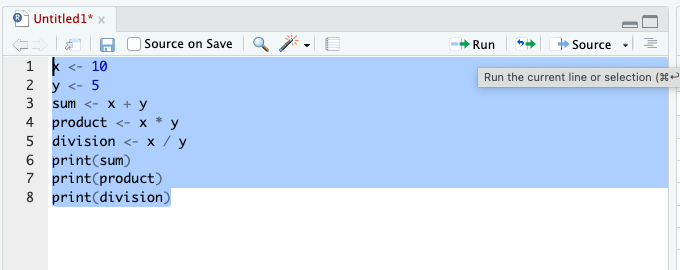

Figure 8. Highlighted portion of code executed by clicking the “Run” button

To save a script, click on the scripts pane, then select “File -> Save As” from the menu bar and put it in your working directory.

## 6.5 R files

R has the native format .RData, which allows you to store multiple objects. To save data as an RData file, use the `save` function. The first argument specifies the R object to be saved, followed by a file argument that defines the file name or path. Below an example to store three R objects (a, b, and c) in an RData file:

```r
a<-1
b<-c(1:5)
c<-"Hallo World"
save(a,b,c, file = "myobjects.RData")
```

The file will be saved in the working directory you set up. Then, to load the saved file run the command:

```r
load("myobjects.RData")
```

# 7. Summary

You’ve made significant progress so far. You’ve started communicating using the R language by writing instructions, executing them via the command line, and customising functions. Occasionally, the computer may provide feedback, such as when an error occurs, but most of the time, it simply performs the requested task and shows the outcome.

The two key elements of R are objects, which store data, and functions, which process and manipulate that data. R also includes several operators (e.g., +, -, *, /, and <-) for performing basic operations. As a data scientist, you’ll use R objects to hold data in your computer’s memory and R functions to automate processes and perform complex calculations.